# Лабораторная работа №5

Построение графиков

Дурдалыев Максат

Российский университет дружбы народов имени Патриса Лумумбы, Москва, Россия

2025-11-08

## Докладчик

- Дурдалыев Максат
- Cтудент НКНбд-01-22
- Российский университет дружбы народов имени Патриса Лумумбы
- 1132205337@pfur.ru
- https://github.com/mdurdalyyev

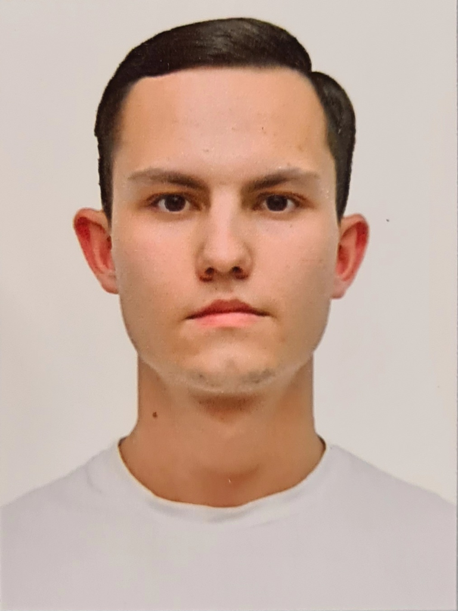

## Цели и задачи

**Цель работы**

Основная цель работы — освоить синтаксис языка Julia для построения графиков.

**Задание**

1. Используя Jupyter Lab, повторите примеры. При этом дополните графики обозначениями осей координат, легендой с названиями траекторий, названиями графиков и т.п.
2. Выполните задания для самостоятельной работы.

## Основные пакеты для работы с графиками в Julia

Рассмотрим построение графика функции f(x) = (3x2 + 6x − 9)e−0,3x разными способами:

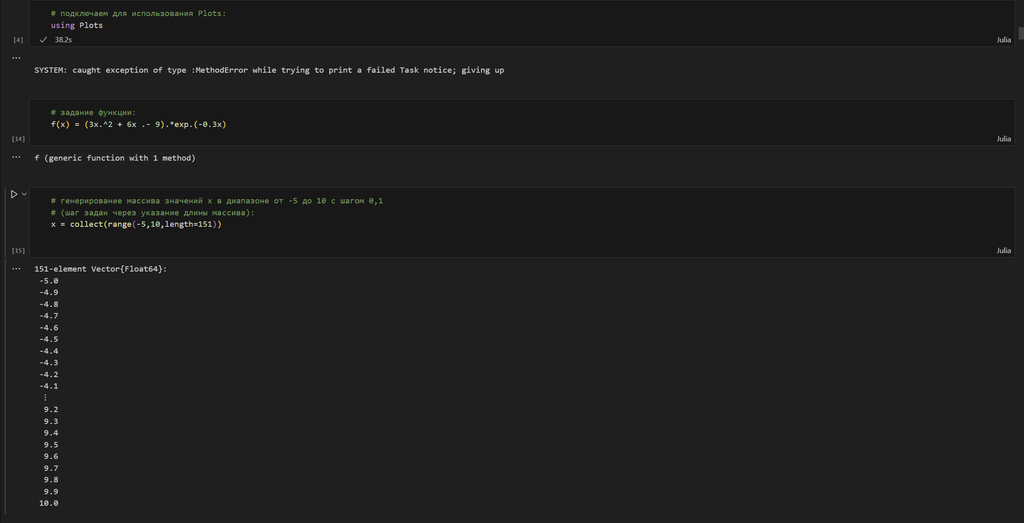

Задание функции

## Основные пакеты для работы с графиками в Julia

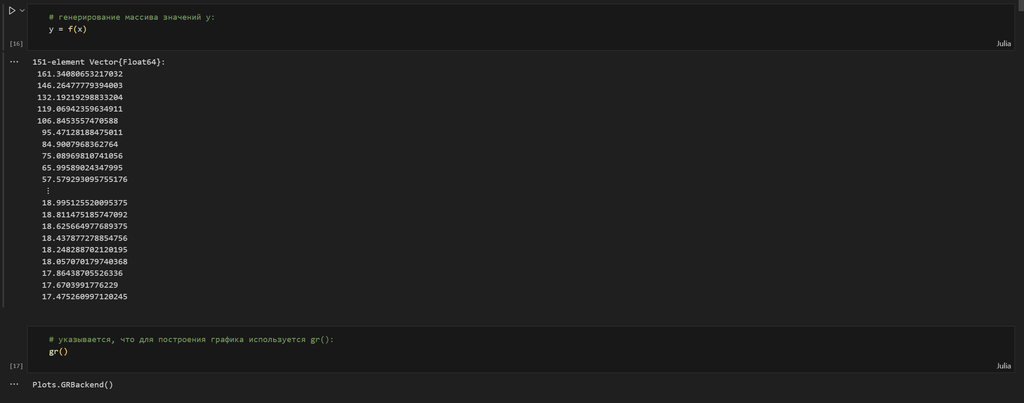

Задание функции

## Основные пакеты для работы с графиками в Julia

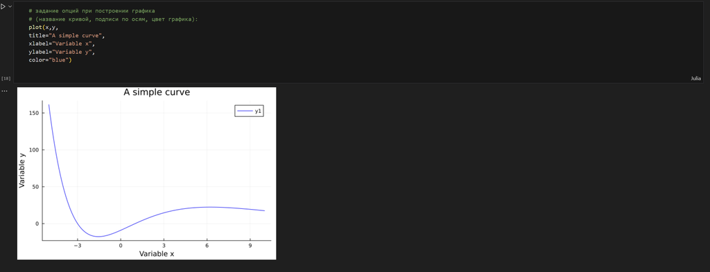

График функции, построенный при помощи gr()

## Основные пакеты для работы с графиками в Julia

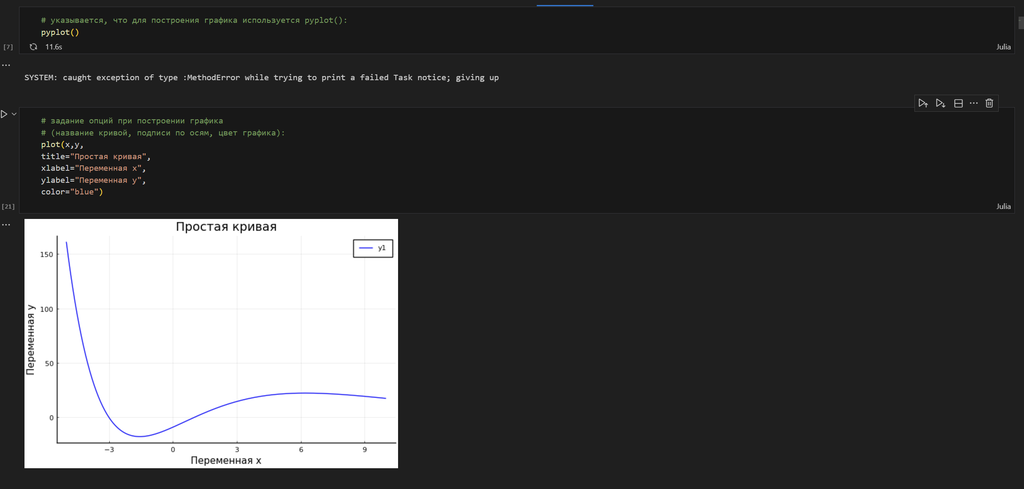

График функции, построенный при помощи pyplot()

## Основные пакеты для работы с графиками в Julia

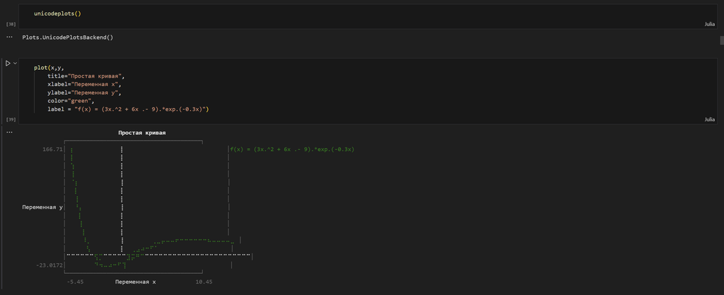

График функции, построенный при помощи unicodeplots()

## Опции при построении графика

На примере графика функции sin(x) и графика разложения этой функции в ряд Тейлора рассмотрим дополнительные возможности пакетов для работы с графикой:

## Опции при построении графика

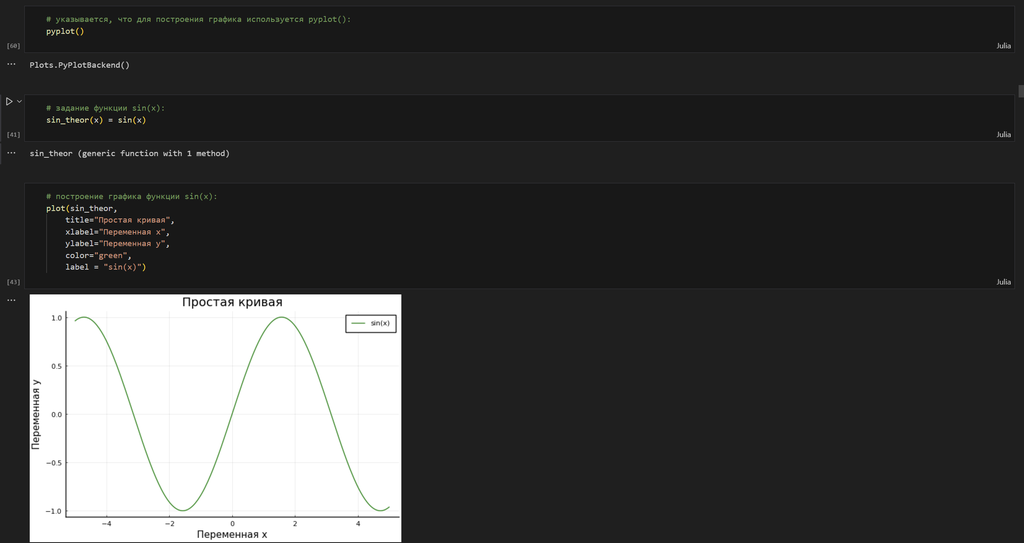

График функции sin(x)

## Опции при построении графика

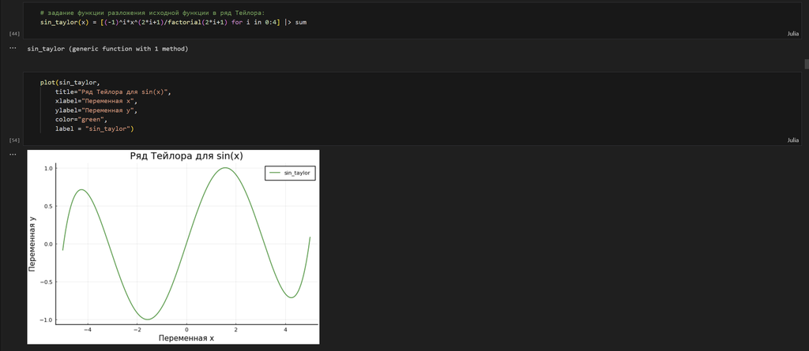

График функции разложения исходной функции в ряд Тейлора

## Опции при построении графика

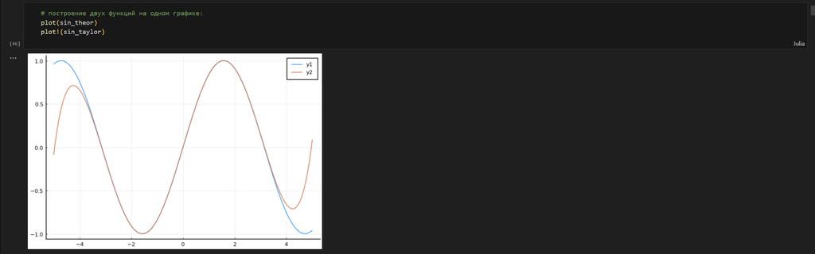

Графики исходной функции и её разложения в ряд Тейлора

## Опции при построении графика

Затем добавим различные опции для отображения на графике:

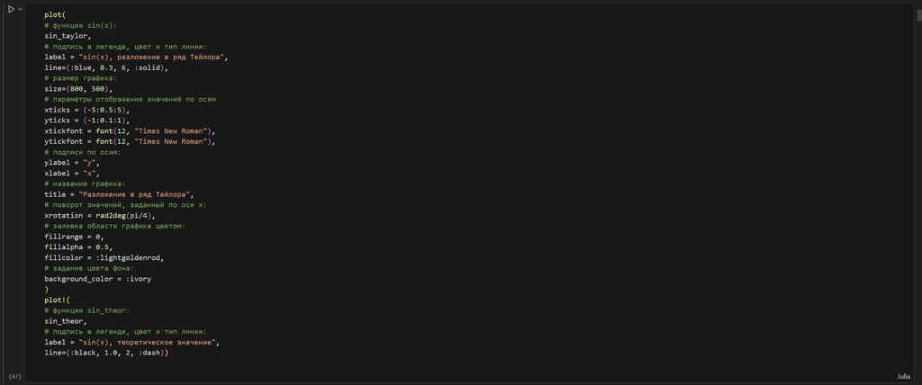

Добавления опций для графика

## Опции при построении графика

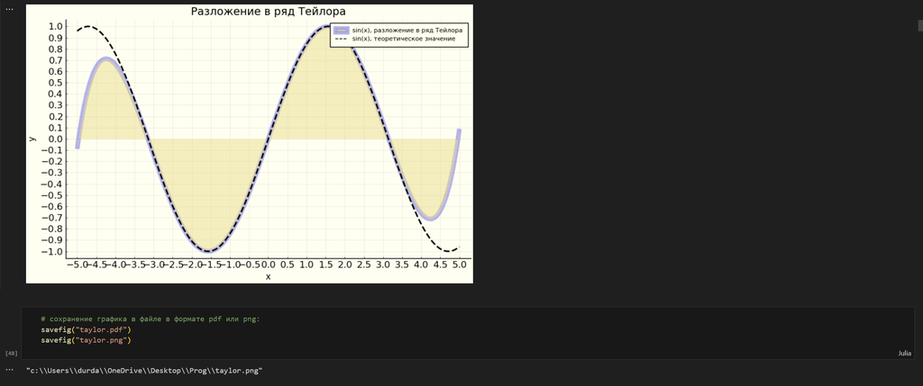

Вид графиков после добавления опций при их построении

## Точечный график

Как и при построении обычного графика для точечного графика необходимо задать массив значений х, посчитать или задать значения у, задать опции построения графика:

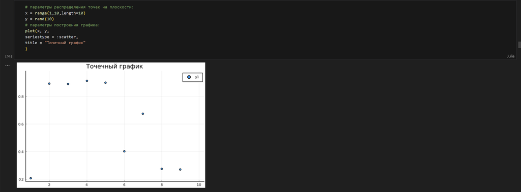

График десяти случайных значений на плоскости (простой точечный график)

## Точечный график

Для точечного графика можно задать различные опции, например размер маркера, его тип, цвет и и т.п.:

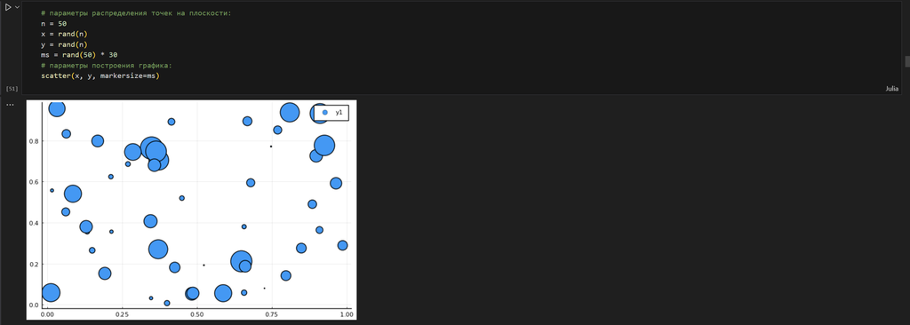

График пятидесяти случайных значений на плоскости с различными опциями отображения (точечный график с кодированием значения размером точки)

## Точечный график

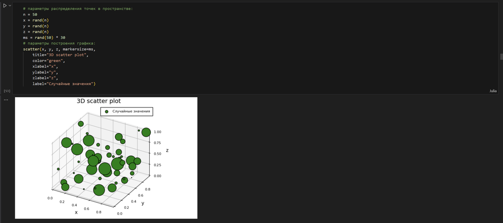

График пятидесяти случайных значений в пространстве с различными опциями отображения (3-мерный точечный график с кодированием значения размером точки)

## Аппроксимация данных

Аппроксимация — научный метод, состоящий в замене объектов их более простыми аналогами, сходными по своим свойствам.

Для демонстрации зададим искусственно некоторую функцию, в данном случае похожую по поведению на экспоненту:

## Аппроксимация данных

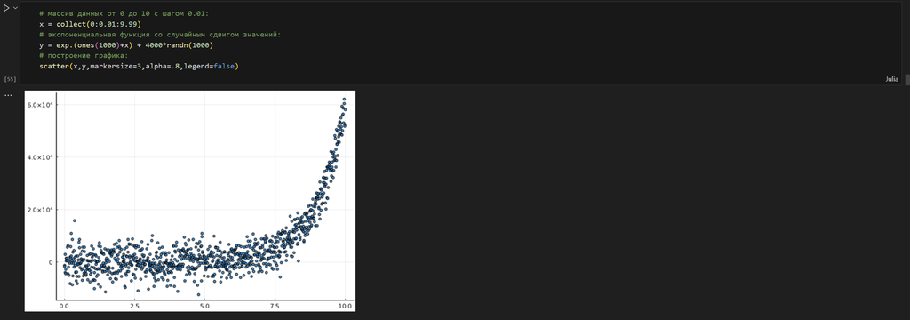

Пример функции

## Аппроксимация данных

Аппроксимируем полученную функцию полиномом 5-й степени:

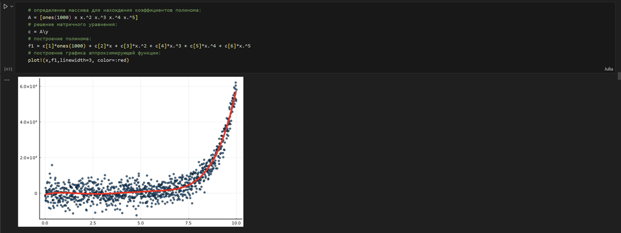

Пример аппроксимации исходной функции полиномом 5-й степени

## Пример траектории

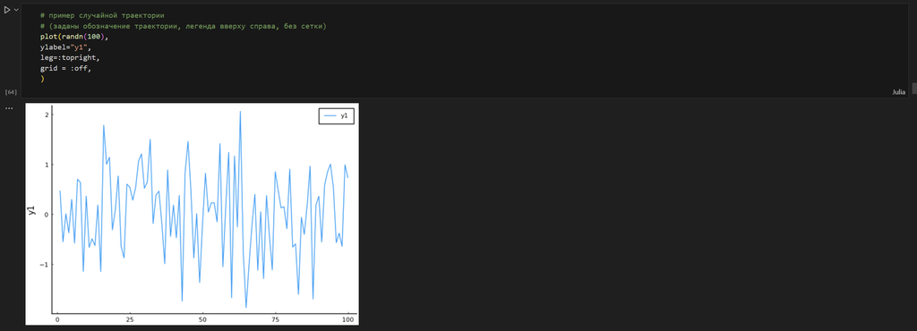

Пример отдельно построенной траектории

## Полярные координаты

Приведём пример построения графика функции в полярных координатах:

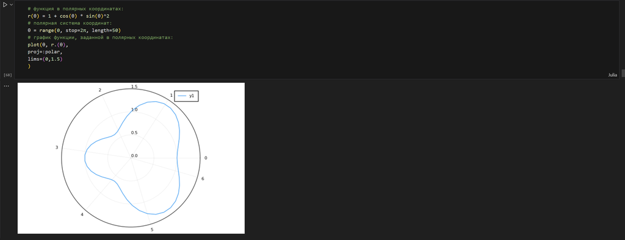

График функции, заданной в полярных координатах

## Параметрический график

Приведём пример построения графика параметрически заданной кривой на плоскости:

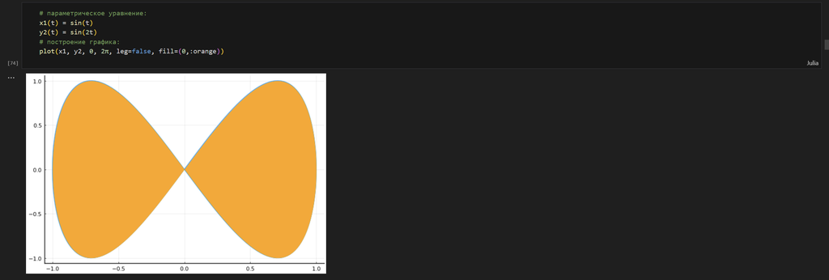

Параметрический график кривой на плоскости

## Параметрический график

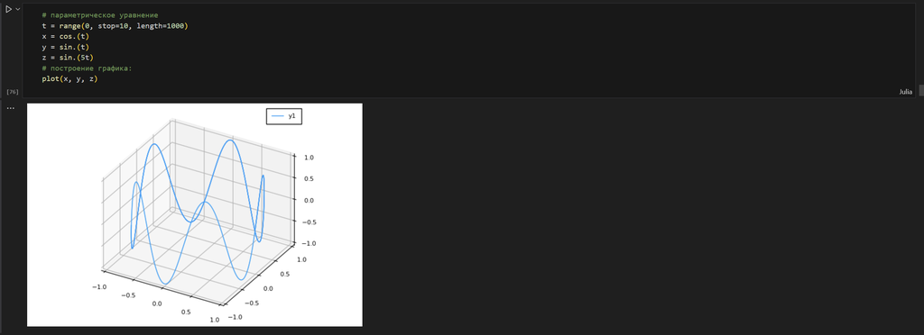

Параметрический график кривой в пространстве

## График поверхности

Для построения поверхности, заданной уравнением f(x, y) = x2 + y2, можно воспользоваться функцией surface():

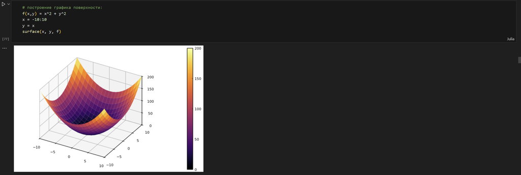

График поверхности (использована функция surface())

## График поверхности

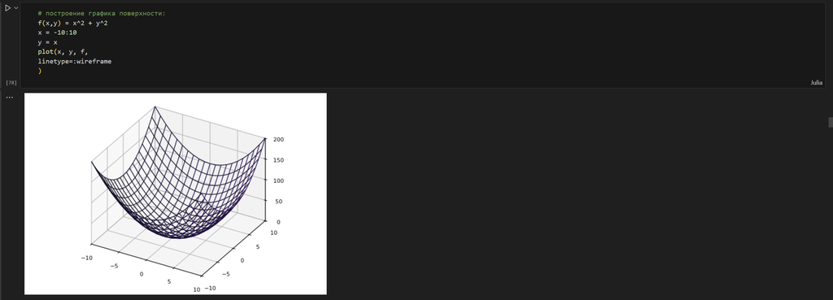

График поверхности (использована функция plot())

## График поверхности

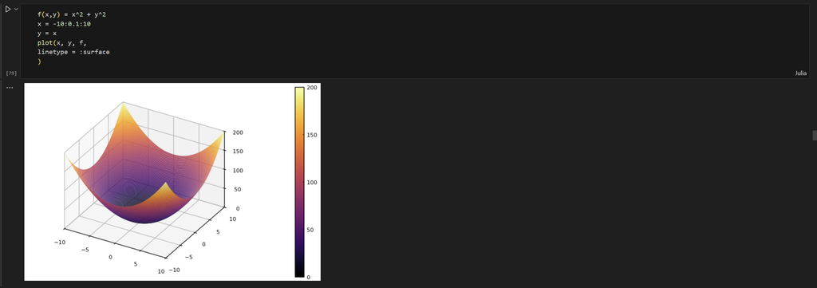

Сглаженный график поверхности

## График поверхности

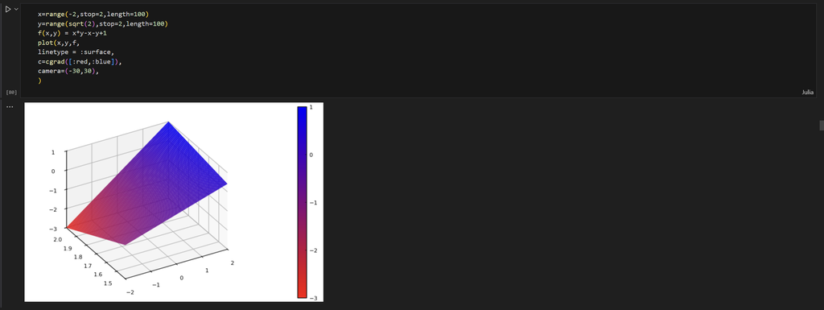

График поверхности с изменённым углом зрения

## Линии уровня

Линией уровня некоторой функции от двух переменных называется множество точек на координатной плоскости, в которых функция принимает одинаковые значения. Линий уровня бесконечно много, и через каждую точку области определения можно провести линию уровня.

С помощью линий уровня можно определить наибольшее и наименьшее значение исходной функции от двух переменных. Каждая из этих линий соответствует определённому значению высоты.

Поверхности уровня представляют собой непересекающиеся пространственные поверхности.

## Линии уровня

Рассмотрим поверхность, заданную функцией g(x, y) = (3x + y2)| sin(x) + cos(y)|:

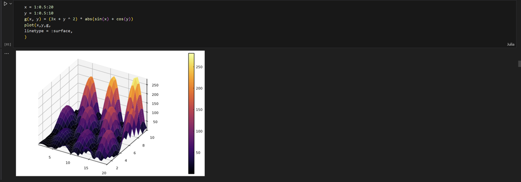

График поверхности, заданной функцией g(x, y) = (3x + y2)| sin(x) + cos(y)|

## Линии уровня

Линии уровня можно построить, используя проекцию значений исходной функции на плоскость:

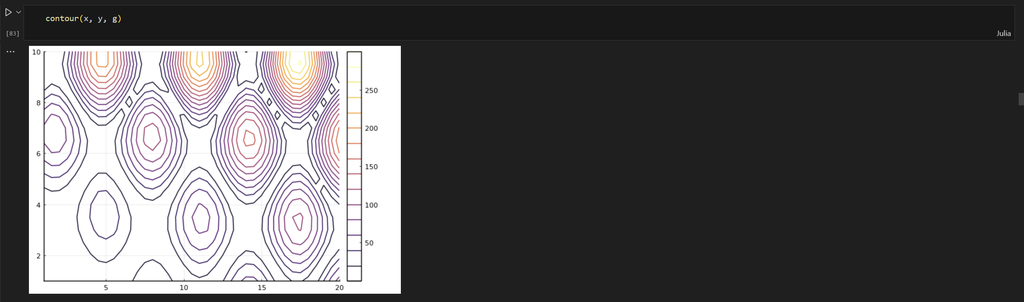

Линии уровня

## Линии уровня

Можно дополнительно добавить заливку цветом:

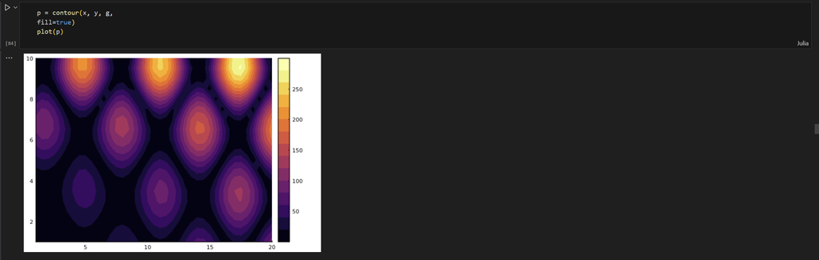

Линии уровня с заполнением

## Векторные поля

Если каждой точке некоторой области пространства поставлен в соответствие вектор с началом в данной точке, то говорят, что в этой области задано векторное поле.

Векторные поля задают векторными функциями.

## Векторные поля

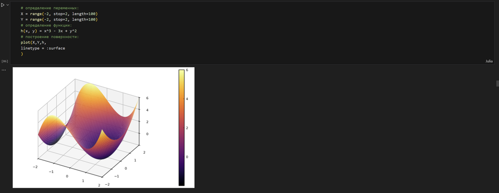

График функции h(x, y) = x3 − 3x + y2

## Векторные поля

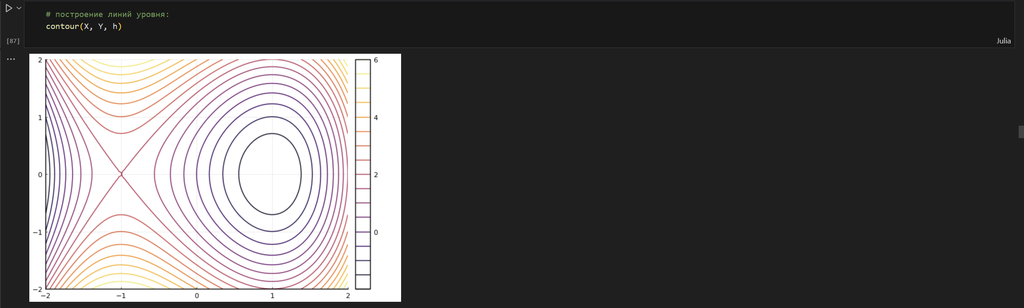

Линии уровня для функции h(x, y) = x3 − 3x + y2

## Анимация

Технически анимированное изображение представляет собой несколько наложенных изображений (или построенных в разных точках графиках) в одном файле.

В Julia рекомендуется использовать gif-анимацию в pyplot().

## Анимация

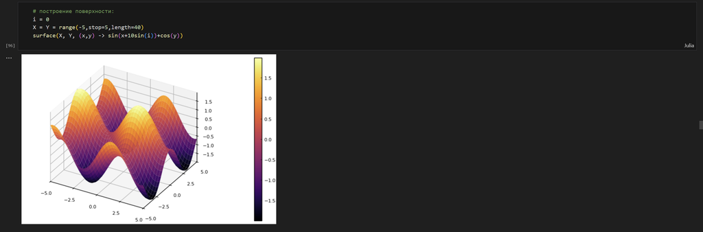

Статичный график поверхности

## Анимация

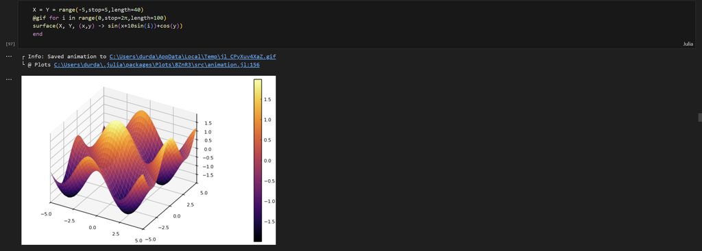

Анимированный график поверхности